# Homework session 1

Eystein Nordby Meese

15 10 2019

# 1 Data transformation

## 1.1 Dplyr

I kodene under finner man løsning for fart, strekning og flest besøk for dplyr-pakken.

```r
# Average speed in kilometers per hour
df1 <- df %>%
  mutate(average_speed_kph = ((distance_trip/10)/(duration_minutes/60))/100)

select(df1, duration_minutes:average_speed_kph)
```

```
## # A tibble: 97,749 x 6
##    duration_minutes month wday  time_of_day_sta~ distance_trip
##               <dbl> <dbl> <fct>            <int>         <dbl>
##  1               19     6 6                   10           330
##  2               17     6 6                   10          1733
##  3                8     6 6                   11          1405
##  4                7     6 6                   11           898
##  5               29     6 6                   11           637
##  6                8     6 6                   11           655
##  7                8     6 6                   11          1228
##  8               10     6 6                   12           898
##  9               29     6 6                   12          1257
## 10                8     6 6                   12          1702
## # ... with 97,739 more rows, and 1 more variable: average_speed_kph <dbl>
```

```r
# Finn de 10 mest populære strekningen
df_top10 <- df1 %>%
  group_by(start_station_name, end_station_name) %>%
  summarise(Number_of_occurances = n()) %>%
  ungroup() %>%
  top_n(wt = Number_of_occurances, n = 10)

df_top10
```

```
## # A tibble: 10 x 3
##    start_station_name     end_station_name Number_of_occurances
##    <chr>                  <chr>                           <int>
##  1 Bergen jernbanestasjon Møllendalsplass                   653
##  2 Møllendalsplass        Gulating                          605
##  3 Møllendalsplass        Nonneseterplass                  1303
##  4 Nonneseterplass        Møllendalsplass                  1220
##  5 Nykirken               Småstrandgaten                    941
##  6 Nykirken               Tårnplass                         595
##  7 Nøstetorget            Cornerteateret                    569
##  8 Småstrandgaten         Nykirken                          574
##  9 Solheimsviken          Media City                        659
## 10 Tårnplass              Nykirken                          775
```

```r
# Stasjon med flest totalt antall besøk
df_visited_top10 <- df1 %>%
  select(start_station_name, end_station_name) %>%
  gather(variable, station) %>%
  group_by(station) %>%
  summarise(count = n()) %>%
  top_n(wt = count, n = 10) %>%
  arrange(desc(count))

df_visited_top10
```

```
## # A tibble: 10 x 2
##    station                count
##    <chr>                  <int>
##  1 Møllendalsplass        12891
##  2 Småstrandgaten         12460
##  3 Solheimsviken          12298
##  4 Cornerteateret         12136
##  5 Tårnplass              11678
##  6 Nykirken               10314
##  7 Bergen jernbanestasjon  9711
##  8 Høyteknologisenteret    8669
##  9 Gulating                8573
## 10 Nonneseterplass         8506
```

Under importeres datasettet “rain” og deretter vises fremgangsmåte for data transformeringen

```r
rain <- read.csv("Data/rain.csv")

# rain filtrert på datoen 01-07-2018

df_filtered <- df %>%
  mutate(date = as.Date(started_at)) %>%
  filter(date >= "2018-07-01")

rain$date <- as.Date(rain$date)

rain_df <- left_join(df_filtered, rain, by = "date")

rain1 <- rain_df %>%
  mutate(rain_category = case_when(
    rain == 0 ~ "Ingen regn",
    rain > 0 & rain < 5 ~ "Litt regn",
    rain >= 5 ~ "Mye regn"
    ))

rain1
```

```
## # A tibble: 97,252 x 21
##    started_at          ended_at            duration start_station_id
##    <dttm>              <dttm>                 <dbl>            <dbl>
##  1 2018-07-01 04:11:18 2018-07-01 04:18:22      423                7
##  2 2018-07-01 05:25:10 2018-07-01 05:31:59      408               24
##  3 2018-07-01 05:27:08 2018-07-01 05:34:35      446                5
##  4 2018-07-01 06:24:15 2018-07-01 06:44:35     1219                5
##  5 2018-07-01 06:25:01 2018-07-01 06:44:50     1188                5
##  6 2018-07-01 07:02:33 2018-07-01 07:18:42      969                5
##  7 2018-07-01 07:14:05 2018-07-01 07:23:25      559               82
##  8 2018-07-01 07:33:06 2018-07-01 07:40:17      431               24
##  9 2018-07-01 07:36:35 2018-07-01 07:40:17      222               58
## 10 2018-07-01 07:37:21 2018-07-01 07:57:27     1206               33
## # ... with 97,242 more rows, and 17 more variables:
## #   start_station_name <chr>, start_station_description <chr>,
## #   start_station_latitude <dbl>, start_station_longitude <dbl>,
## #   end_station_id <dbl>, end_station_name <chr>,
## #   end_station_description <chr>, end_station_latitude <dbl>,
## #   end_station_longitude <dbl>, duration_minutes <dbl>, month <dbl>,
## #   wday <fct>, time_of_day_started <int>, distance_trip <dbl>,
## #   date <date>, rain <dbl>, rain_category <chr>
```

```r
rain2 <- rain1 %>%
  distinct(date, .keep_all = TRUE) %>%
  group_by(rain_category) %>%
  summarise(Number_of_days = n()) %>%
  mutate(rain_share = paste0(round((Number_of_days/sum(Number_of_days))*100, 2),"%"))

rain2
```

```
## # A tibble: 3 x 3
##   rain_category Number_of_days rain_share
##   <chr>                  <int> <chr>
## 1 Ingen regn                57 31.15%
## 2 Litt regn                 45 24.59%
## 3 Mye regn                  81 44.26%
```

```r
# Oppgave 5
df_filtered_rain <- rain1 %>%
  group_by(rain_category) %>%
  summarise(Average_ride = mean(duration_minutes))

df_filtered_rain
```

```
## # A tibble: 3 x 2
##   rain_category Average_ride
##   <chr>                <dbl>
## 1 Ingen regn           10.4
## 2 Litt regn            10.5
## 3 Mye regn              9.50
```

Det ser ut som gjennomsnittsturen er noe lavere ved mye regn kontra ingen regn, men det er ikke en veldig stor differanse mellom intervallene.  
En slik snittberegning er ikke tilstrekkelig for å trekke en kausal sammenheng mellom mengde nedbør og lengde på sykkelturene fordi vi for eksempel ikke vet hvor mange observasjoner vi har i de forskjellige regnkategoriene. Det kan være veldig mange observasjoner for når det ikke regner, mens det kan være veldig få når det ikke regner, slik at vi ikke har et stort nok utvalg til å kunne trekke en konklusjon med høy nok confidence. Et annet punkt er at vi ikke vet hvor langt en person som sykler hadde tenkt til å sykle før det begynte å regne. Bysyklene blir som regel brukt for å komme seg fra A til B, ikke sykle rundt i byen på sightseeing. Dermed er det vanskelig å si noe om sykkelturene ville vært kortere eller lenger, med høy sikkerhet, når det regner mye kontra når det regner lite/ikke regner.

## 1.2 Data Table

I kodene under finner man løsning for fart, strekning og flest besøk for data.table pakken.

```r
dt <- setDT(df)

# Average speed in kilometers per hour
df_dt <- dt[, ':=' (average_speed_kph=(((distance_trip/10)/(duration_minutes/60))/100))]
df_dt[,duration_minutes:average_speed_kph]
```

```
##        duration_minutes month wday time_of_day_started distance_trip
##     1:               19     6    6                  10           330
##     2:               17     6    6                  10          1733
##     3:                8     6    6                  11          1405
##     4:                7     6    6                  11           898
##     5:               29     6    6                  11           637
##    ---
## 97745:                6    12    2                  20           988
## 97746:                6    12    2                  21           837
## 97747:               15    12    2                  21          2996
## 97748:               15    12    2                  21          2996
## 97749:                4    12    2                  22           525
##        average_speed_kph
##     1:          1.042105
##     2:          6.116471
##     3:         10.537500
##     4:          7.697143
##     5:          1.317931
##    ---
## 97745:          9.880000
## 97746:          8.370000
## 97747:         11.984000
## 97748:         11.984000
## 97749:          7.875000
```

```r
# Finn de 10 mest populære strekningen
dt_top10 <- dt[, .(amount = uniqueN(.SD)), by = c("start_station_name", "end_station_name")]
dt_top10[order(-amount), .SD[1:10]]
```

```
##         start_station_name end_station_name amount
##  1:        Møllendalsplass  Nonneseterplass   1303
##  2:        Nonneseterplass  Møllendalsplass   1220
##  3:               Nykirken   Småstrandgaten    941
##  4:              Tårnplass         Nykirken    775
##  5:          Solheimsviken       Media City    659
##  6: Bergen jernbanestasjon  Møllendalsplass    653
##  7:        Møllendalsplass         Gulating    605
##  8:               Nykirken        Tårnplass    595
##  9:         Småstrandgaten         Nykirken    574
## 10:            Nøstetorget   Cornerteateret    569
```

```r
# Stasjon med flest totalt antall besøk
dt_visited_top10 <- setDT(list(unlist(dt[,c(5,10)])))[,.N, keyby = V1]
names(dt_visited_top10) <- c("Station Name", "Count")
dt_visited_top10[order(-Count), .SD[1:10]]
```

```
##               Station Name Count
##  1:        Møllendalsplass 12891
##  2:         Småstrandgaten 12460
##  3:          Solheimsviken 12298
##  4:         Cornerteateret 12136
##  5:              Tårnplass 11678
##  6:               Nykirken 10314
##  7: Bergen jernbanestasjon  9711
##  8:   Høyteknologisenteret  8669
##  9:               Gulating  8573
## 10:        Nonneseterplass  8506
```

# 2 Data vasking (tidyr)

## 2.1 Tell and spre

```r
df_pivot <- df %>%
  group_by(start_station_name, end_station_name) %>%
  summarise(Number_of_occurances = n()) %>%
  pivot_wider(names_from = end_station_name,
              values_from = Number_of_occurances)

df_pivot
```

```
## # A tibble: 38 x 39
## # Groups:   start_station_name [38]
##    start_station_n~ Akvariet `Allehelgens pl~ `Bergen jernban~
##    <chr>               <int>            <int>            <int>
##  1 ADO arena              12               53              126
##  2 Akvariet               NA               49              152
##  3 Allehelgens pla~       38               NA              117
##  4 Bergen jernbane~      161               94               NA
##  5 Cornerteateret         90               78              307
##  6 Den Nationale S~       88               18              101
##  7 Den nationale s~       49                3               24
##  8 Grieghallen            72               40               71
##  9 Gulating              228               17              306
## 10 Haukeland sykeh~        5                4               27
## # ... with 28 more rows, and 35 more variables: Cornerteateret <int>, `Den
## #   Nationale Scene` <int>, `Den nationale scene 1` <int>,
## #   Grieghallen <int>, Gulating <int>, `Haukeland sykehus` <int>,
## #   `Høgskulen på Vestlandet` <int>, Høyteknologisenteret <int>,
## #   Johanneskirken <int>, Jonsvollkvartalet <int>, Klosteret <int>,
## #   Lysverket <int>, `Media City` <int>, Møllendalsplass <int>,
## #   Neumannsgate <int>, Nonneseterplass <int>, Nykirken <int>,
## #   Nøstetorget <int>, Rådhuset <int>, `Sandviken Brygge` <int>,
## #   Sandvikstorget <int>, Småstrandgaten <int>, Solheimsviken <int>,
## #   Studentboligene <int>, `Studentboligene ved Grønneviken` <int>,
## #   `Studentsenteret UIB` <int>, Tårnplass <int>, Verftet <int>, `Østre
## #   Murallmeningen` <int>, `ADO arena` <int>, `Høyskolen på
## #   Vestlandet` <int>, Klostertet <int>, Sandviksbodene <int>, `Lars
## #   Hilles` <int>, `Media Bergen` <int>
```

## 2.2 Samling

```r
df_pivot_longer <- df %>%
  mutate(id = row_number()) %>%
  pivot_longer(cols = ends_with("name"),
               names_to = "stasjon",
               values_to = "value",
               names_prefix = "name") %>%
  select(id:value)

df_pivot_longer
```

```
## # A tibble: 195,498 x 3
##       id stasjon            value
##    <int> <chr>              <chr>
##  1     1 start_station_name Grieghallen
##  2     1 end_station_name   Bergen jernbanestasjon
##  3     2 start_station_name Studentsenteret UIB
##  4     2 end_station_name   Akvariet
##  5     3 start_station_name Tårnplass
##  6     3 end_station_name   Høyteknologisenteret
##  7     4 start_station_name Høyteknologisenteret
##  8     4 end_station_name   Bergen jernbanestasjon
##  9     5 start_station_name Tårnplass
## 10     5 end_station_name   Lysverket
## # ... with 195,488 more rows
```

# 3 Visualisering

## 3.1 Density

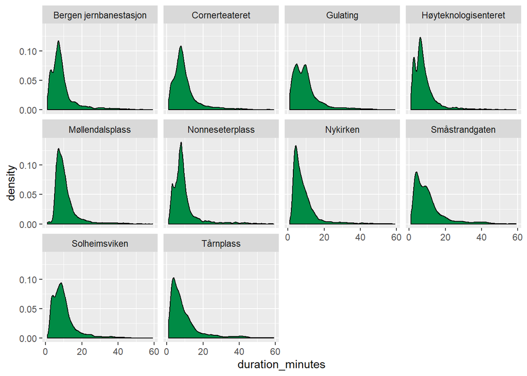

```r
df_top_stations <- df %>%
  filter(start_station_name %in% df_visited_top10$station)

ggplot(df_top_stations, aes(duration_minutes)) +
  geom_density(fill = "springgreen4") +
  facet_wrap(~start_station_name)
```

## 3.2 Ridges

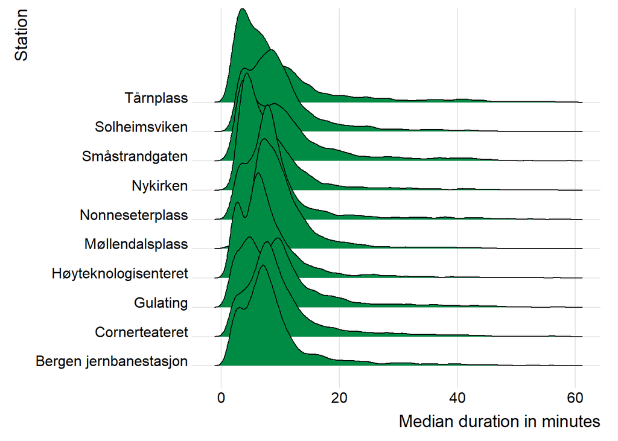

```r
ggplot(df_top_stations, aes(x = duration_minutes, y = start_station_name)) +
  geom_density_ridges(scale = 4, fill = "springgreen4") + theme_ridges() +
  labs(y = "Station",
       x = "Median duration in minutes")
```

## 3.3 Sortering

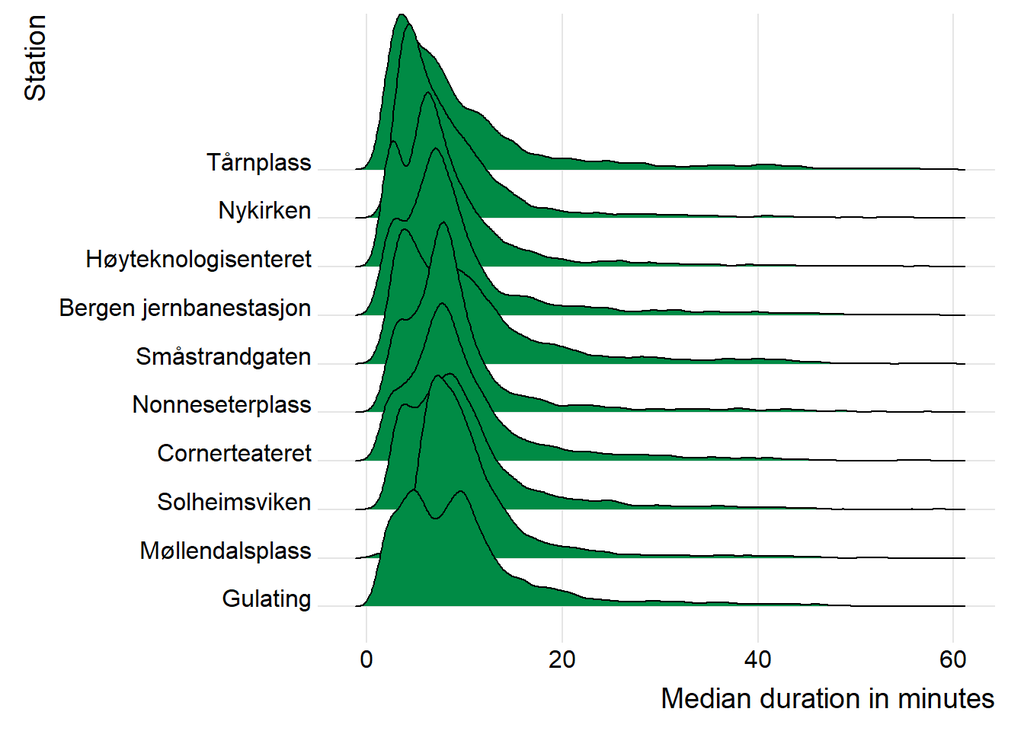

```r
p <- df_top_stations %>%
  mutate(start_station_name = fct_reorder(start_station_name, desc(duration_minutes), .fun = "median")) %>%
  ggplot(aes(x = duration_minutes, y = start_station_name)) +
  geom_density_ridges(scale = 4, fill = "springgreen4") + theme_ridges() +
  labs(y = "Station",
       x = "Median duration in minutes")

p
```

## 3.4 Grusomt barplott

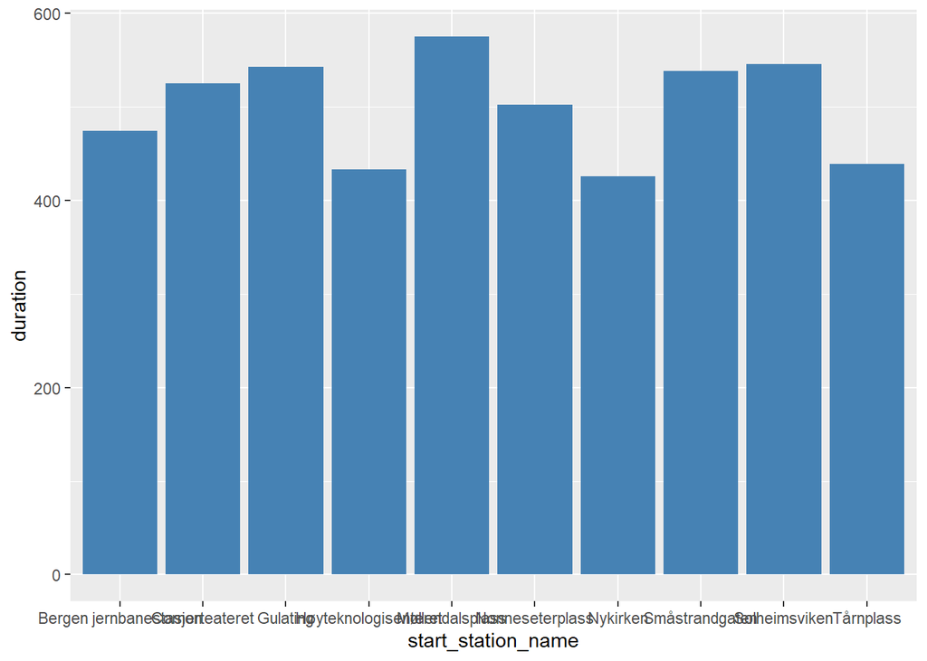

```r
ggplot(df_top_stations, aes(x = start_station_name, y = duration)) +
  geom_bar(stat = "summary", fun.y = "median", fill = "steelblue")
```

## 3.5 Fiks barplottet

```r
myColors <- brewer.pal(10, name = "Set3")
names(myColors) <- df_visited_top10$start_station_name
```

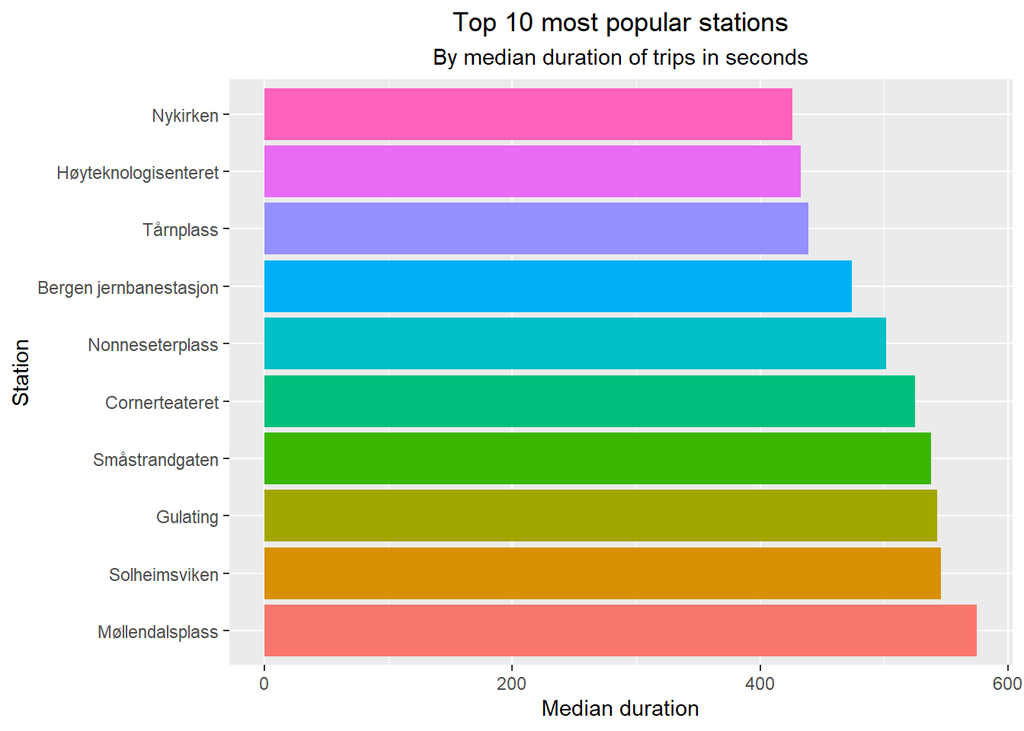

```r
df_top_stations %>%
  mutate(start_station_name = fct_reorder(start_station_name, desc(duration), .fun = "median")) %>%
  ggplot(aes(x = start_station_name, y = duration, fill = start_station_name)) +
  geom_bar(stat = "summary", fun.y = "median") +
  scale_colour_manual(values = myColors) +
  coord_flip() +
  labs(y = "Median duration",
       x = "Station",
       title = "Top 10 most popular stations",
       subtitle = "By median duration of trips in seconds") +
  theme(plot.title = element_text(hjust = 0.5),
        plot.subtitle = element_text(hjust = 0.5),
        legend.position = "none")
```

## 3.6 Opphetet diskusjon

Illustrer sammenhengen mellom nedbørsmengde og varighet på sykkelturen. Ta gjerne utgangspunktet i kun et utvalg av strekninger. Forklar funnene.

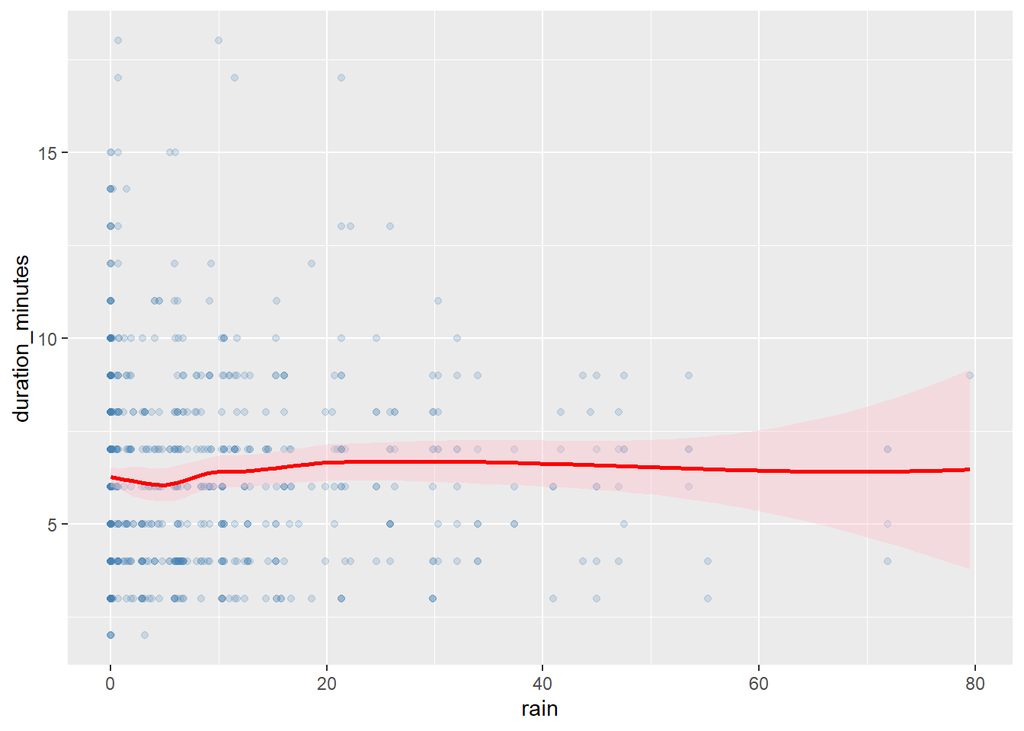

```r
rain_duration <- rain1 %>%
  filter(start_station_name == c("Møllendalsplass", "Nykirken",
                                 "Nøstetorget", "Solheimsviken") &
         end_station_name == c("Nonneseterplass", "Småstrandgaten",
                               "Cornerteateret", "Media City"),
         duration >= 150 & duration <= 1200)


ggplot(rain_duration, aes(x = rain, y = duration_minutes)) +
  geom_point(alpha = .2, color = "steelblue") +
  geom_smooth(color = "red", fill = "pink")
```

Fra grafen ser vi lengden i minutter på turene på strekningene:  
- Møllendalsplas til Nonneseterplass  
- Nykirken til Småstrandgaten  
- Nøstetorget til Cornerteateret  
- Solheimsviken til Media City  
Det er filtrert ut turer som varte under 2,5 eller over 20 minutter, da disse ser ut til å være outliers.  
Når vi analyserer grafen, ser vi at det ikke er stor forskjell i tidsbruken på rutene med økende regnvær. Men vi ser at når det regner “litt”, så går snittiden på turene litt ned, før den øker med mer regn igjen. Ergo, vi kan ikke konkludere med at det er noen sammenheng mellom nedbørsmengden og varigheten på sykkelturene.  
Det vi dermed kan se, er at antall sykkelturer drastisk synker med økende nedbørsmengde, slik at vi kan konkludere med at flere og flere velger andre fremkostmidler når nedbørsmengden øker.

## 3.7 En GIF sier mer en tusen bilder

[figure not shown]

```r
p_mdp <- df_mdp %>%
  mutate(started_at_date = as.Date(started_at)) %>%
  group_by(started_at_date) %>%
  summarise(NumberOfTrips = n())

p <- ggplot(p_mdp, aes(x = started_at_date, y = NumberOfTrips)) +
  geom_line() +
  labs(title = "Antall turer fra Møllendal over tid") +
  theme(plot.title = element_text(hjust = 0.5))

p + transition_reveal(started_at_date)
```

## 3.8 Nettverk

```r
df_end_stations <- df %>%
  group_by(start_station_name, end_station_name) %>%
  summarise(Number_of_trips = n())

nodes <- df_end_stations %>%
 ungroup() %>%
 select(start_station_name) %>%
 rename(id = start_station_name) %>%
 mutate(label = id, group = id) %>%
 distinct()

edges <- df_end_stations %>%
 ungroup() %>%
 rename(from = start_station_name, to = end_station_name)

visNetwork(nodes, edges, width = "100%") %>%
  visNodes(shape = "circle", color = id) %>%
  visEdges(arrows = "from", "to") %>%
  visInteraction(navigationButtons = TRUE) %>%
  visOptions(nodesIdSelection = TRUE) %>%
  visLegend()
```

[interactive chart not shown]

# 4 Fri oppgave

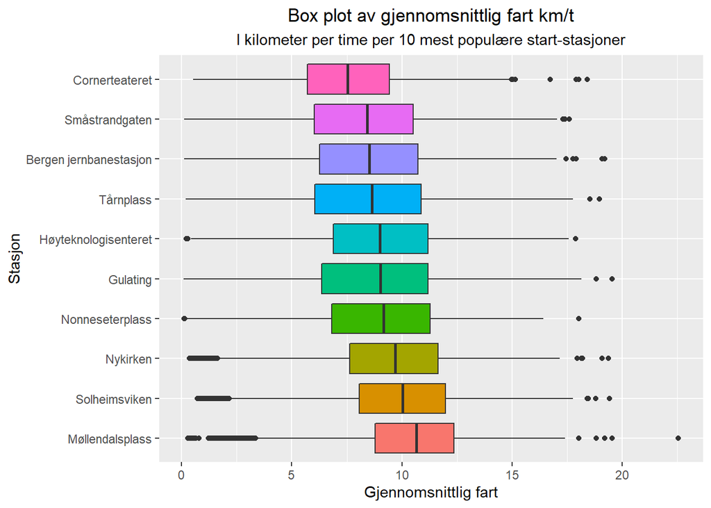

```r
# Lager dataset med top 10 stasjoner og filter på maks fart
df_top_stations_speed <- df1 %>%
  filter(start_station_name %in% df_visited_top10$station) %>%
   mutate(average_speed_kph = ((distance_trip/10)/(duration_minutes/60))/100) %>%
  filter(average_speed_kph <= 80) %>%
  filter(duration_minutes >= 3 & duration_minutes <= 60)

df_top_stations_speed %>%
  mutate(start_station_name = fct_reorder(start_station_name, desc(average_speed_kph))) %>%
  ggplot(aes(start_station_name, average_speed_kph)) +
  geom_boxplot(aes(fill = start_station_name)) +
  coord_flip() +
  scale_y_continuous("Gjennomsnittlig fart", breaks = seq(0,25, by = 5)) +
  labs(title = "Box plot av gjennomsnittlig fart km/t",
       subtitle = "I kilometer per time per 10 mest populære start-stasjoner",
       x = "Stasjon") +
  theme(plot.title = element_text(hjust = 0.5),
        plot.subtitle = element_text(hjust = 0.5),
        legend.position = "none")
```

Her vises et boxplot av turene fra de 10 mest besøkte start-stasjonene og den gjennomsnittlige farten på sykkelturene som startet i disse stasjonene. Jeg fjernet observasjoner der farten var over 80 km/t, da dette kan betegnes som outliers (ikke normalt for en bysykkel å komme opp i over 80 km/t). Jeg fjerner også turer under 3 minutter, da disse kan virke som man har begynt på en tur for så å stoppe/snu med en gang. Også fjernet turer over 60 minutter, da jeg ønsker å se på farten til en vanlig A til B tur, ikke en rolig “søndagstur” eller sightseeing.

Plotet viser at de fleste turene ligger gjennomsnittlig på 10 km/t, med de høyeste observasjonene rundt 20 km/t. Med andre ord virker det som de fleste turene går i et forholdsvis rolig tempo. Dette virker fornuftig, da man vil tro de mer “seriøse” og “fanatiske” syklistene eier egne mer spesialiserte landeveissykler, terrengsykler eller en hybridvariant. Og det er disse som ofte sykler i et godt høyere tempo.

Man vil likevel kunne tro farten ligger litt høyere enn dette når det sykles, da disse turene foregår i en stor by, hvor det vil være mye start og stopp i trafikken.